# Clustering Traffic Accidents Using K-Means Clustering

### Interpretation:

- Most states have alcohol fatalities clustered in lower ranges (under ~400).
- A few extreme values (e.g., >1000) suggest outliers—likely populous states like California or Texas.
- Distribution is right-skewed, meaning a few states experience disproportionately high fatalities.

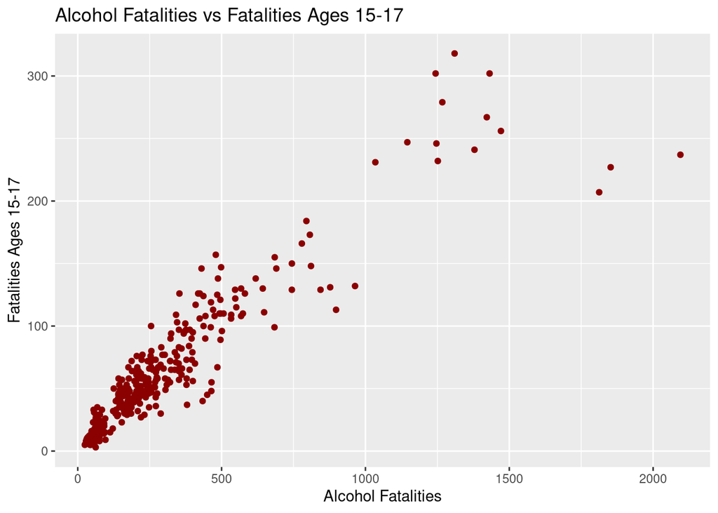

```r
scatter_1517 <- ggplot(Fatalities_Grouped_By_State, aes(x = afatal, y = fatal1517)) +
  geom_point(color = "darkred") +
  labs(title = "Alcohol Fatalities vs Fatalities Ages 15-17",
       x = "Alcohol Fatalities", y = "Fatalities Ages 15-17")
print(scatter_1517)
```

### Interpretation:

- A positive trend is visible: states with higher afatal tend to have more teen fatalities.
- However, there is scatter and noise, suggesting other factors also influence teen fatalities (e.g., policy, enforcement).

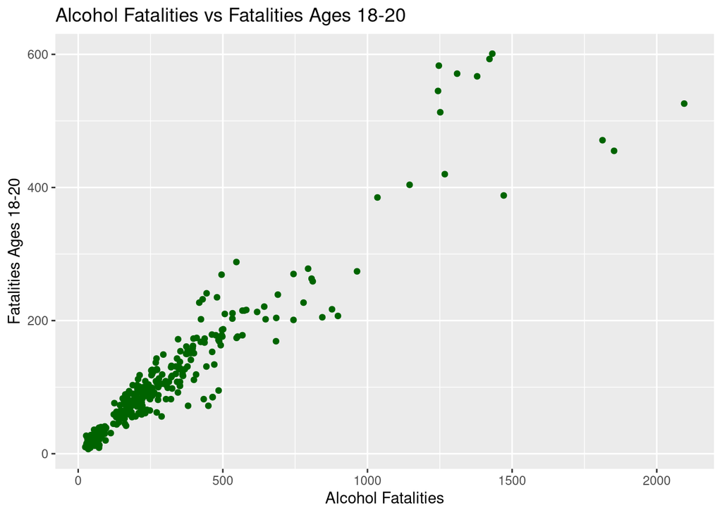

```r
scatter_1820 <- ggplot(Fatalities_Grouped_By_State, aes(x = afatal, y = fatal1820)) +
  geom_point(color = "darkgreen") +
  labs(title = "Alcohol Fatalities vs Fatalities Ages 18-20",
       x = "Alcohol Fatalities", y = "Fatalities Ages 18-20")
print(scatter_1820)
```

### Interpretation:

- Shows a stronger linear relationship than with ages 15–17.
- Suggests this age group contributes more significantly to overall alcohol fatalities.
- Could point to risky behavior or access to alcohol in college-age populations.

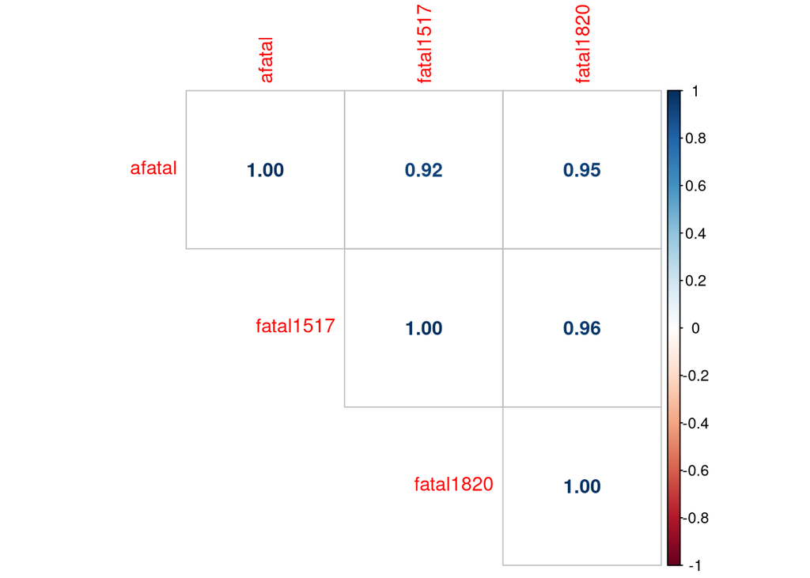

```r
# Load required libraries
library(dplyr)
library(corrplot)

# Select numeric columns
numeric_cols <- Fatalities_Grouped_By_State %>%
  select(afatal, fatal1517, fatal1820)

# Compute correlation matrix
cor_matrix <- cor(numeric_cols, use = "complete.obs")

# Plot the correlation matrix
corrplot(cor_matrix, method = "number", type = "upper")
```

## Modeling and Results

This section details the data preprocessing, modeling approach, and key findings, weaving a narrative about how the data reveals patterns in traffic accident fatalities across U.S. states from 1982–1988. The story focuses on identifying high-risk areas and understanding the role of alcohol and young drivers in fatal crashes.

### Data Preprocessing and Cleaning

To ensure robust clustering, the “Fatalities.csv” dataset was meticulously preprocessed:

- Variable Selection: Focused on afatal (alcohol-related fatalities), fatal1517 (fatalities ages 15–17), and fatal1820 (fatalities ages 18–20) to capture alcohol-related and teen-related accident patterns, critical for identifying high-risk hotspots.
- Missing Data Check: No missing or null values were found, ensuring data integrity.
- Outlier Removal: Outliers were identified using the interquartile range (IQR) method, removing values beyond ( Q1 - 1.5 IQR ) or ( Q3 + 1.5 IQR ) to prevent skewing cluster centroids.
- Feature Scaling: Standardized afatal, fatal1517, and fatal1820 to a mean of 0 and standard deviation of 1, as K-Means clustering relies on Euclidean distance, and unscaled data could bias results.

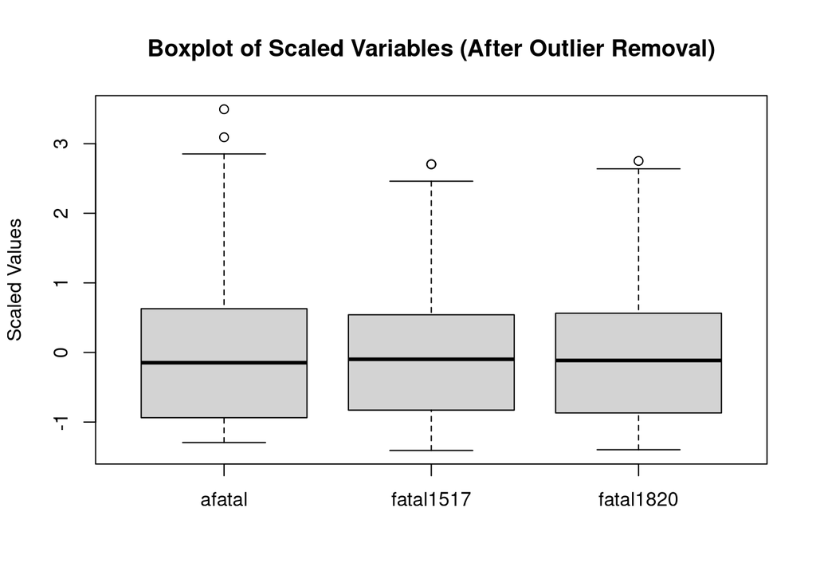

```r
# Define a function to detect outliers using the IQR method
detect_outliers <- function(x) {
  q1 <- quantile(x, probs = 0.25, na.rm = TRUE)
  q3 <- quantile(x, probs = 0.75, na.rm = TRUE)
  iqr <- q3 - q1
  x < (q1 - 1.5 * iqr) | x > (q3 + 1.5 * iqr)
}

# Define a function to eliminate rows with outliers from specified columns
eliminate_outliers <- function(df, cols = names(df)) {
  for (col in cols) {
    df <- df[!detect_outliers(df[[col]]), ]
  }
  return(df)
}

# Specify the columns to check for outliers
target_columns <- c("afatal", "fatal1517", "fatal1820")

# Remove rows with outliers in the target columns
cleaned_data <- eliminate_outliers(Fatalities_Grouped_By_State, target_columns)

# Scale the cleaned data for clustering or further analysis
scaled_data <- scale(cleaned_data[, target_columns])

# Visualizing Scaled Data
boxplot(
  scaled_data,
  ylab = "Scaled Values",
  main = "Boxplot of Scaled Variables (After Outlier Removal)"
)
```

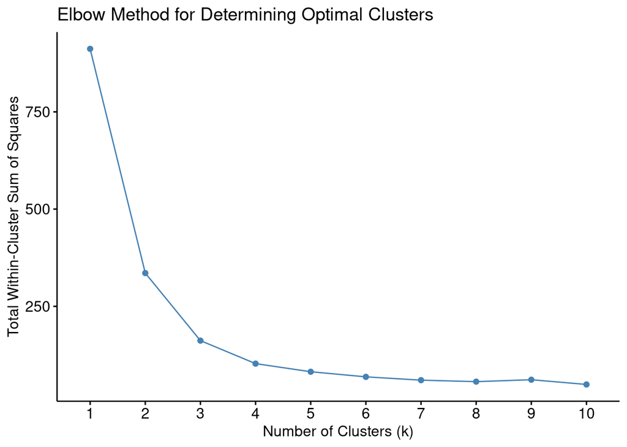

```r
# Determining Optimal Number of Clusters: Elbow Method
library(factoextra)  # For visualizing clustering results

# Apply the Elbow Method using within-cluster sum of squares (WSS)
fviz_nbclust(
  scaled_data,             # The scaled data prepared for clustering
  FUNcluster = kmeans,     # Clustering method: k-means
  method = "wss"           # WSS: within-cluster sum of squares
) +
  labs(
    title = "Elbow Method for Determining Optimal Clusters",
    x = "Number of Clusters (k)",
    y = "Total Within-Cluster Sum of Squares"
  )
```

- ```
  The Elbow Method plot shows the within-cluster sum of squares (WCSS) decreasing as the number of clusters increases, with a noticeable "elbow" at ( K = 3 ).
  ```

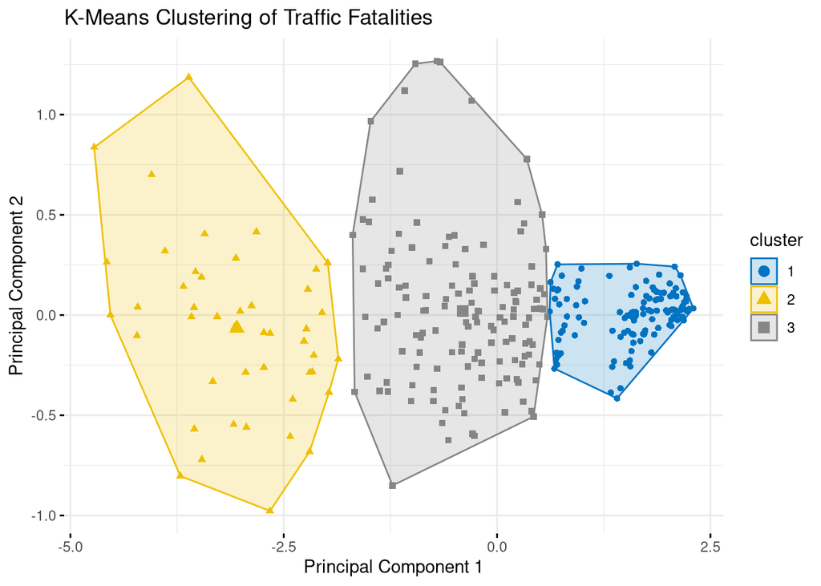

```r
# K-Means Clustering of Traffic Fatalities
set.seed(123)

# Perform K-Means clustering with 3 clusters and 25 random starts
kmeans_result <- kmeans(
  scaled_data,      # Scaled data
  centers = 3,      # Number of clusters
  nstart = 25       # Number of random initial configurations
)

# Add the cluster assignments to the cleaned dataset
cleaned_data$cluster <- as.factor(kmeans_result$cluster)

# Visualizing the Clusters
library(factoextra)

# Visualize the clusters using fviz_cluster
fviz_cluster(
  object = kmeans_result,          # K-means result object
  data = scaled_data,              # Scaled data used for clustering
  ellipse.type = "convex",         # Convex hull around clusters
  geom = "point",                  # Points for each observation
  palette = "jco",                 # Color palette
  ggtheme = theme_minimal()        # Minimal ggplot theme
) +
  labs(
    title = "K-Means Clustering of Traffic Fatalities",
    x = "Principal Component 1",
    y = "Principal Component 2"
  )
```

- ```
  The visualization shows data points grouped into three clusters with convex ellipses, indicating clear separation and validating the choice of ( K = 3 ).
  ```

```r
library(dplyr)
library(knitr)
library(kableExtra)

# Create cluster summary
cluster_summary <- cleaned_data %>%
  group_by(cluster) %>%
  summarise(
    across(where(is.numeric), ~ mean(.x, na.rm = TRUE)),
    state = NA_character_,
    .groups = "drop"
  )

# Display the summary nicely
cluster_summary %>%
  kable(caption = "Table: Average Values of Numeric Variables by Cluster", digits = 2, booktabs = TRUE) %>%
  kable_styling(full_width = FALSE, position = "center")
```

Table: Average Values of Numeric Variables by Cluster

| cluster | year | afatal | fatal1517 | fatal1820 | state |
| --- | --- | --- | --- | --- | --- |
| 1 | 1985.04 | 81.76 | 19.02 | 31.54 | NA |
| 2 | 1985.13 | 475.01 | 108.47 | 175.07 | NA |
| 3 | 1984.92 | 255.68 | 56.31 | 93.80 | NA |

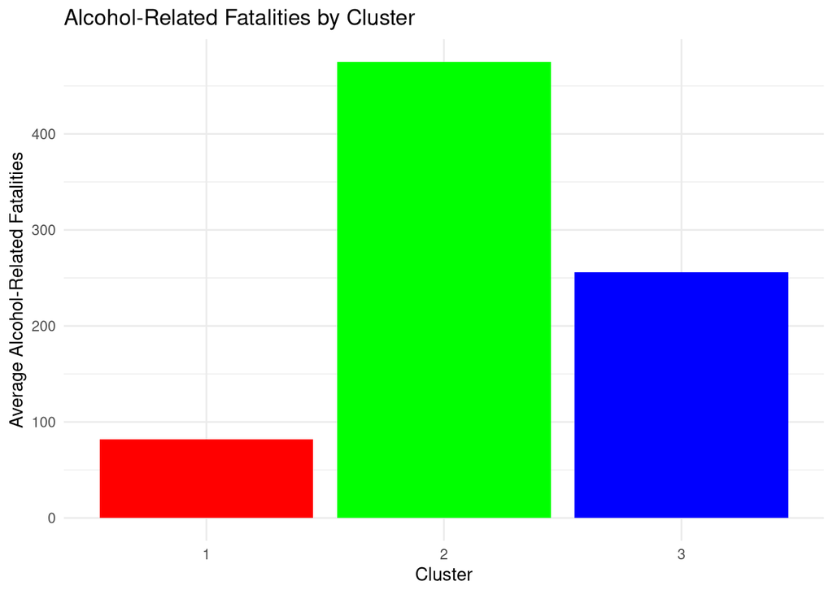

```r
# ---------------------------------------------------------
# Bar Plot: Alcohol-Related Fatalities by Cluster
# ---------------------------------------------------------

# Load required library
library(ggplot2)

# Create bar plot for average alcohol-related fatalities per cluster
ggplot(cluster_summary, aes(x = cluster, y = afatal, fill = cluster)) +
  geom_bar(
    stat = "identity",
    show.legend = FALSE  # Hides redundant legend since color = cluster
  ) +
  scale_fill_manual(values = c("red", "green", "blue")) +
  labs(
    title = "Alcohol-Related Fatalities by Cluster",
    x = "Cluster",
    y = "Average Alcohol-Related Fatalities"
  ) +
  theme_minimal()
```

- The bar plot visually confirms that Cluster 2 has significantly higher alcohol-related fatalities (475) compared to Cluster 3 (256) and Cluster 1 (81.8).
- This stark contrast underscores Cluster 2 as the primary target for alcohol-related interventions, as its fatalities are nearly six times higher than Cluster 1’s, highlighting the urgency of addressing urban hotspots.
- The distinct heights of the bars reinforce the clustering results, showing clear differentiation in risk levels across the three groups.

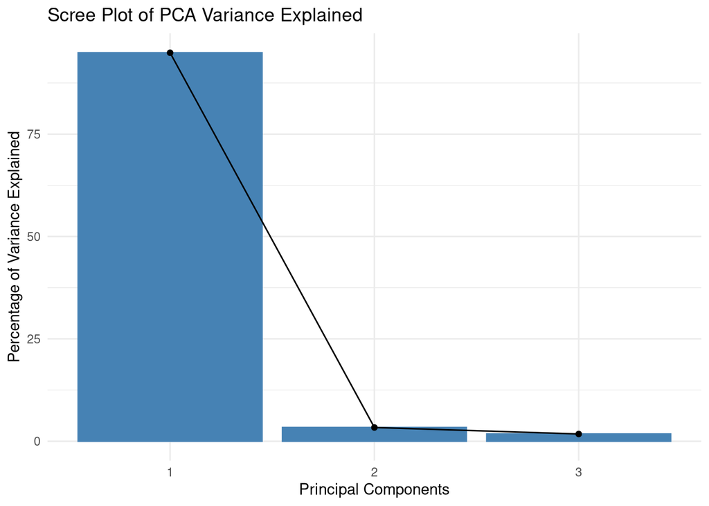

```r
# Principal Component Analysis (PCA)
# Perform PCA on the scaled data
pca_result <- prcomp(
  scaled_data,      # Data already scaled for clustering
  center = TRUE,    # Center the variables
  scale. = TRUE     # Scale the variables to unit variance
)

# Scree Plot: Variance Explained by Principal Components
library(factoextra)

# Visualize the proportion of variance explained by each principal component
fviz_eig(pca_result) +
  labs(
    title = "Scree Plot of PCA Variance Explained",
    x = "Principal Components",
    y = "Percentage of Variance Explained"
  ) +
  theme_minimal()
```

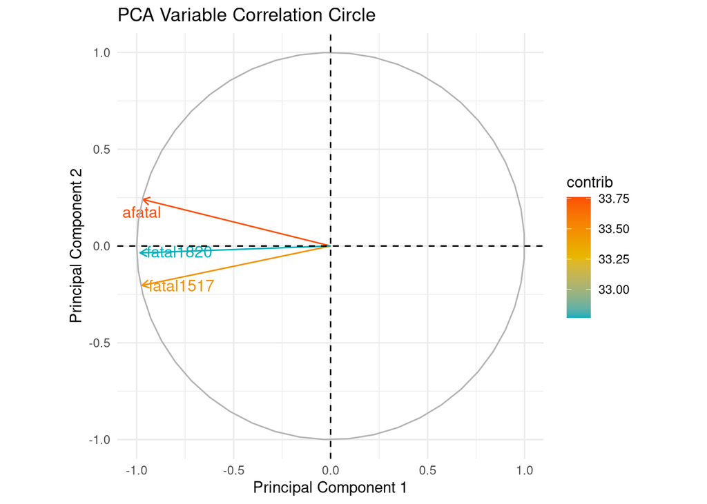

```r
# PCA Variable Correlation Circle
# Visualize how original variables contribute to the principal components
fviz_pca_var(
  pca_result,                       # PCA result object
  col.var = "contrib",             # Color by contribution to PCs
  gradient.cols = c("#00AFBB", "#E7B800", "#FC4E07"),  # Gradient for contribution
  repel = TRUE                     # Avoid label overlap
) +
  labs(
    title = "PCA Variable Correlation Circle",
    x = "Principal Component 1",
    y = "Principal Component 2"
  ) +
  theme_minimal()
```

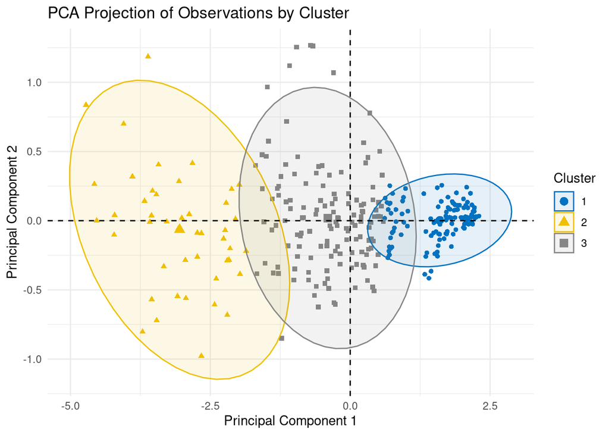

```r
# PCA Projection of Observations by Cluster
# Visualize observations in the PCA space, colored by cluster
fviz_pca_ind(
  pca_result,                   # PCA result object
  geom.ind = "point",           # Use points to represent observations
  col.ind = cleaned_data$cluster,  # Color points by cluster assignment
  palette = "jco",              # Use a clean and readable color palette
  addEllipses = TRUE,           # Draw ellipses around clusters
  legend.title = "Cluster"      # Title for legend
) +
  labs(
    title = "PCA Projection of Observations by Cluster",
    x = "Principal Component 1",
    y = "Principal Component 2"
  ) +
  theme_minimal()
```

- The PCA projection plot shows individual state-year observations projected onto the first two principal components, colored by cluster with ellipses indicating cluster boundaries.
- Clear separation between clusters validates the K-Means results: Cluster 2 (high-risk) is distinctly separated from Cluster 1 (low-risk), with Cluster 3 (moderate-risk) occupying an intermediate position.
- This separation confirms that the clusters capture meaningful differences in fatality patterns, with Cluster 2’s position reflecting its high afatal and fatal1820 values, reinforcing the urban hotspot narrative.

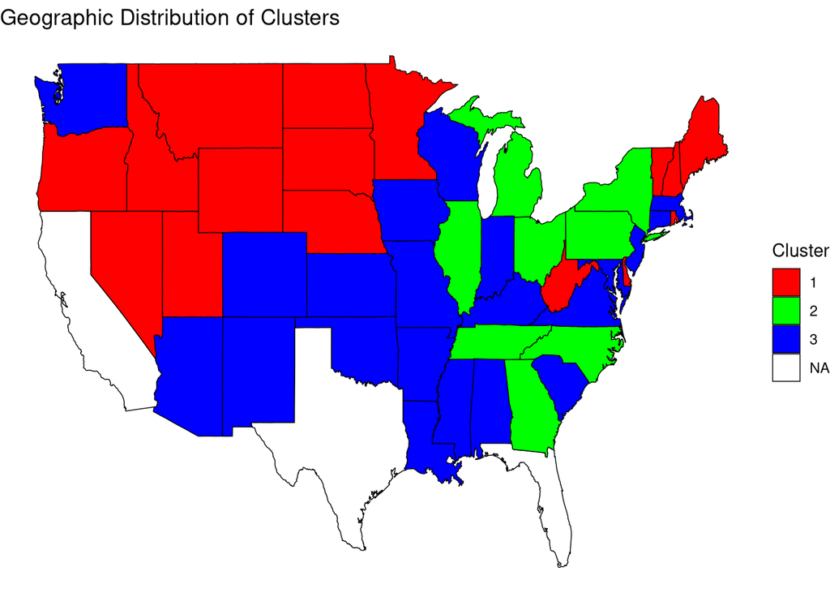

```r
# ---------------------------------------------------------
# Geographic Distribution of Clusters
# ---------------------------------------------------------

# Create a lookup table to map state abbreviations to full state names (lowercase)
state_lookup <- data.frame(
  abbr = tolower(state.abb),
  full = tolower(state.name)
)

# Add special handling for Washington, D.C., which isn't included in base R state vectors
state_lookup <- rbind(
  state_lookup,
  data.frame(abbr = "dc", full = "district of columbia")
)

# Convert state abbreviations in the dataset to full state names
cleaned_data$state <- state_lookup$full[match(tolower(cleaned_data$state), state_lookup$abbr)]

# Prepare Data for Mapping -  Get U.S. map data from ggplot2
us_map <- map_data("state")

# Assign cluster values to map data based on matching state names
us_map$cluster <- cleaned_data$cluster[match(us_map$region, cleaned_data$state)]
us_map$cluster <- as.factor(us_map$cluster)

# Plotting the U.S. Map Colored by Cluster
library(ggplot2)
library(maps)

# Plot the map with states filled by cluster color
ggplot(us_map, aes(x = long, y = lat, group = group, fill = cluster)) +
  geom_polygon(color = "black", linewidth = 0.25) +
  theme_void() +  # Clean, borderless map
  scale_fill_manual(
    values = c("red", "green", "blue"),
    na.value = "white"  # States with no cluster info shown in white
  ) +
  labs(
    title = "Geographic Distribution of Clusters",
    fill = "Cluster"
  )
```